# TITLE by Mohamed Fouly Sayed Ibrahim

# Quality.level and alcohol:

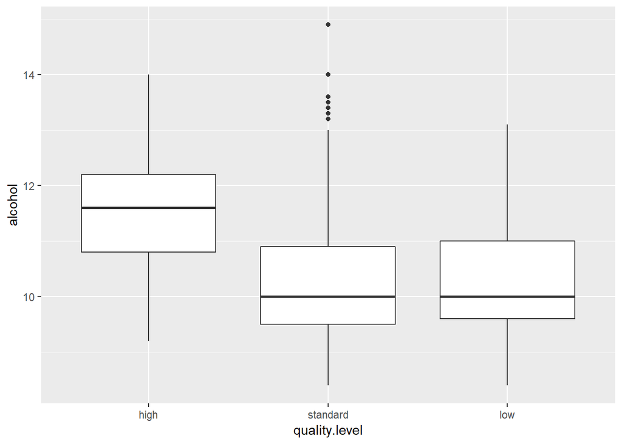

High quality level has high alcohol content while medium and low quality levels have lower alcohol content

# Quality.level and pH :

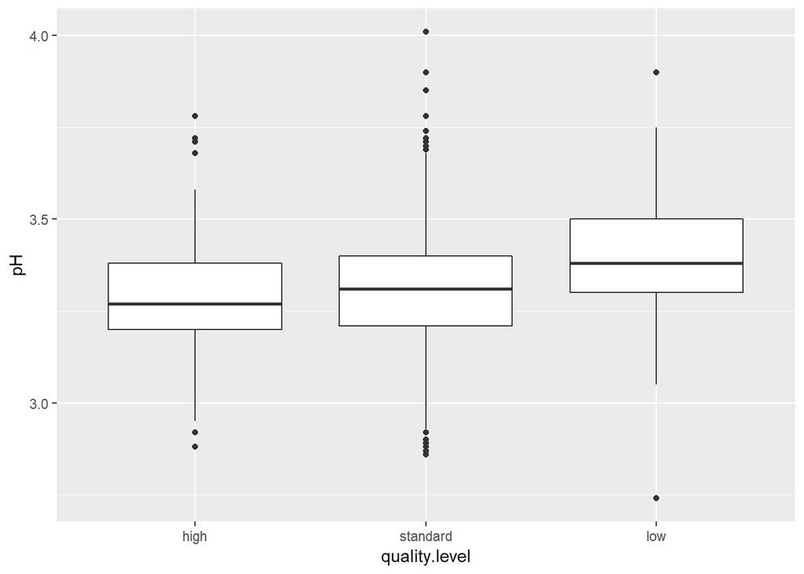

high quality level has low pH level

# Quality level and density:

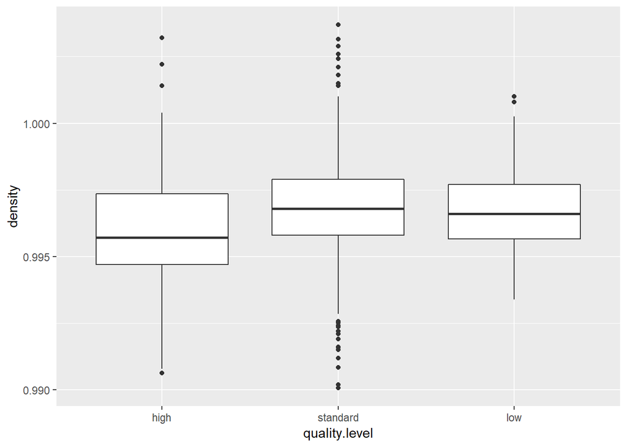

medium quality.level has higher density than low and high high quality.level has low density than other quality.levels

# quality.level and volatile acidity:

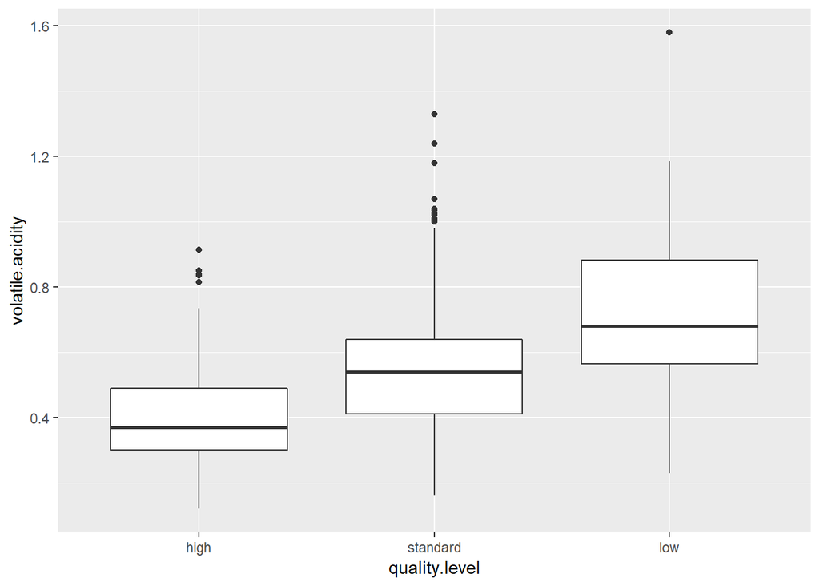

high quality.level wine has low volatile acidity while low quality ones has higher volatile acidity

# Bivariate Analysis

### Talk about some of the relationships you observed in this part of the investigation. How did the feature(s) of interest vary with other features in the dataset?

- the quality increases as alcohol increases
- High quality level has high alcohol content while medium and low quality levels
- have lower alcohol content
- high quality level has low pH level
- medium quality.level has higher density than low and high high quality.level has low density than other quality.levels

### Did you observe any interesting relationships between the other features (not the main feature(s) of interest)?

- high quality.level wine has low volatile acidity, while low quality ones has higher volatile acidity

### What was the strongest relationship you found?

- the quality of wine is positively correlated to alcohol also volatile acidity is negatively correlated to quality

# Multivariate Plots Section:

# multivariate plot no 1 :

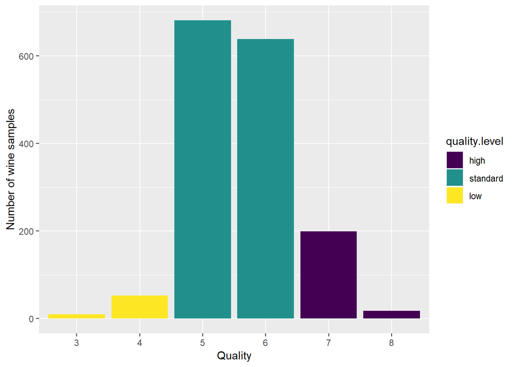

most of wines has quality(5,6) ,low quantity have a quality (3,4)

# multivariate plot no2:

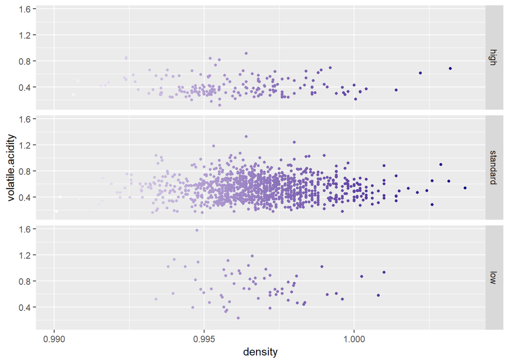